# Credit Default Prediction Model Card

Author

Owen Simon

## Home Credit Predictive Lending Summary

### Business Context

Many potential borrowers lack sufficient credit histories, making it difficult to evaluate creditworthiness. To responsibly expand access to credit, Home Credit must leverage alternative data sources to assess repayment risk for these applicants.

### Analytics Approach

A machine learning model has been developed to estimate the probability that each applicant will successfully repay a loan. Key points: - Inputs include customer application information and alternative data such as telecommunications records. - Outputs are expressed as repayment probabilities, which guide decisions on loan approval, loan amount, and loan term. - The model was trained using LASSO regression with cross-validation to ensure generalizability and mitigate overfitting.

### Expected Impact

- **Broaden financial inclusion:** Extend credit to qualified borrowers who lack traditional credit histories.
- **Manage default risk:** Identify high-risk applicants and adjust approval or loan terms accordingly.
- **Operational efficiency:** Support faster, data-driven underwriting decisions.

### Caveats and Limitations

- **Data gaps:** Incomplete or inaccurate applicant information may affect predictions.
- **Model constraints:** Linear relationships captured by LASSO may miss complex borrower behaviors.
- **Regulatory and fairness considerations:** Features like gender cannot be used for decision-making; model outputs should be monitored for disparities.
- **Deployment risk:** Applying the model outside the original population or product type without retraining may produce unreliable results.

## 1. Model Details

This section describes the **model type, version, training data, and key hyperparameters**.

### 1.1 - Model Type

- **Algorithm:** LASSO Logistic Regression (`glmnet`)
- **Implementation:** `glmnet` via the `caret` package
- **Training method:** 5-fold cross-validation with SMOTE sampling
- **Objective:** Predict probability of loan default (`TARGET` = 1)

### 1.2 - Model Version

| Attribute | Value |
| --- | --- |
| Model name | Credit Default Prediction Model |
| Algorithm | LASSO Logistic Regression |
| Implementation | `glmnet` via `caret` |
| Training procedure | 5-fold cross-validation |
| Target variable | `TARGET` (1 = default, 0 = repaid) |
| Output | Probability of loan default |

### 1.3 - Training Data Summary

The model was trained on **loan application data** with supplemental credit history datasets. Features were aggregated at the borrower level to produce a comprehensive predictor set.

| Dataset | Description |
| --- | --- |
| `application_train` | Loan applications with demographic, financial, and target information |
| `application_test` | Loan applications without the target variable, used for evaluation |
| `bureau` | Historical credit bureau records |
| `bureau_balance` | Monthly loan balance status from bureau reports |
| `previous_application` | Records of previous loan applications |
| `credit_card_balance` | Credit card balances and repayment behavior |
| `POS_CASH_balance` | Point-of-sale and cash loan repayment history |
| `installments_payments` | Historical installment payment records |

**Target variable:**

- `TARGET = 1` → borrower defaulted
- `TARGET = 0` → borrower repaid

The dataset is **highly imbalanced**, with defaults representing a small proportion of all observations.

### 1.4 - Key Hyperparameters

```
      alpha     lambda
1 0.4789474 0.04065876
```

These hyperparameters were selected using cross-validation on a subset of the training data and SMOTE sampling.

## 2. Intended Use

### 2.1 - Intended Users

This model is designed for use by:

- Credit risk analysts evaluating borrower applications
- Consumer lending decision systems and automated underwriting pipelines
- Risk management teams monitoring portfolio performance

### 2.2 - Decisions Supported

The model supports decisions such as:

- Approving or denying loan applications based on predicted default risk
- Identifying borrowers who may require additional review or manual underwriting
- Prioritizing applications for follow-up or risk-based pricing adjustments

### 2.3 - Out of Scope

This model is **not intended to:**

- Predict repayment amounts or timing beyond default/no-default
- Replace human judgment in underwriting decisions
- Predict defaults in a different population or market without retraining
- Be used outside consumer lending contexts

### 2.4 - Limitations and Risks

While the model supports credit risk evaluation, users should be aware of the following limitations and potential risks:

- **Data Limitations:**  
  Missing, outdated, or inaccurate applicant information may reduce predictive accuracy, particularly for applicants with limited financial histories or incomplete alternative data sources.
- **Model Limitations:**  
  The LASSO model captures linear relationships and may not fully account for complex interactions, rare high-risk profiles, or temporal patterns in repayment behavior. Predictions should be interpreted as risk scores, not guarantees of repayment.
- **Deployment Risks:**  
  Applying the model outside the original population, market, or product type without retraining can lead to unreliable results. Operational errors in preprocessing, feature engineering, or data handling may also compromise predictions.
- **Fairness and Bias Risks:**  
  Certain demographic patterns (e.g., age, education, correlated financial behaviors) can lead to disparities in approval rates. Protected features such as gender are not used for decision-making, but correlated proxies may still influence outcomes. Continuous monitoring, evaluation, and, if necessary, threshold adjustment or model retraining are required to mitigate unintended bias.
- **Regulatory Considerations:**  
  Model outputs must comply with lending regulations, including the Equal Credit Opportunity Act (ECOA). Features that could constitute discriminatory factors (e.g., gender) must never be used in loan decisions, and denial reasons must be explainable to applicants.
- **Generalizability Constraints:**  
  Predictions are valid for the population and products represented in the training data. Applying the model to new geographic regions, loan types, or applicant populations may require retraining or recalibration.

## 3. Performance Metrics

This section evaluates model performance using **Area Under the ROC Curve (AUC)**, as well as **threshold-dependent metrics** including **precision, recall, and loan approval rate** at a chosen decision threshold.

Threshold-dependent metrics are calculated at the optimal threshold identified in Section 4.

### 3.1 Cross-Validated Performance

The model was trained on 80 % of the training dataset using 5-fold cross-validation with SMOTE sampling to address class imbalance, while 20 % of the data was held out as a validation set to evaluate performance on unseen examples.

```
Cross-Validated AUC: 0.7693
```

### 3.2 - Hold-Out Validation Set Performance

Threshold = 0.65

|  | Actual 0 | Actual 1 |
| --- | --- | --- |
| Pred 0 | 50976 | 3144 |
| Pred 1 | 5561 | 1821 |

```
AUC: 0.752
```

```
Precision: 0.2467
```

```
Recall: 0.3668
```

```
Approval Rate: 0.88
```

### 3.3 - Performance Summary Table

The table below compares the cross-validated AUC from training with the validation AUC from the hold-out dataset.

| Metric | Value |
| --- | --- |
| Cross-Validated AUC | 0.7693 |
| Validation AUC | 0.7520 |

The cross-validated AUC and validation AUC are similar, indicating that the model generalizes reasonably well to unseen data and does not show strong evidence of overfitting.

### 3.4 - Kaggle Benchmark

For additional context, model performance can be compared to scores from the *Home Credit Default Risk* Kaggle competition.

| Benchmark | AUC |
| --- | --- |
| Cross-Validated AUC | 0.7693 |
| Validation AUC | 0.7520 |
| Kaggle Public Score | 0.7418 |
| Kaggle Private Score | 0.7304 |

The Kaggle leaderboard scores are slightly lower than the cross-validated and validation AUC values. This is expected because the Kaggle test set represents completely unseen data, while the validation set is drawn from the same distribution as the training data. Minor differences also arise because the private leaderboard is calculated using approximately 80% of the test set.

## 4. Decision Threshold Analysis

### 4.1 - Business Assumptions

Business value assumptions were derived from publicly reported data on unsecured consumer lending. Net interest income on performing unsecured loans typically yields around 12–17 % annually, after accounting for funding and operational costs (Bankrate, 2026; NerdWallet, 2026). Recovery rates on defaulted unsecured loans are low, averaging approximately 40 % of principal, implying a loss given default of roughly 60 % (Moody’s, 2025; New Capital, 2025). These values inform the profit calculations used in the threshold sweep and expected profit analysis.

| Decision | Actual | Value per $1 principal |
| --- | --- | --- |
| Approve | Repaid | $0.12 |
| Approve | Defaulted | -$0.60 |
| Decline | Any | $0 |

**References**

- Bankrate. (2026). *Average personal loan rates for March 2026.* https://www.bankrate.com/loans/personal-loans/average-personal-loan-rates/
- Moody’s. (2025). *Managing defaults in a high yield portfolio.* https://www.newcapital.com/en/usa/insights/Managing-Defaults-in-a-High-Yield-Portfolio.html
- NerdWallet. (2026). *Average personal loan interest rates for March 2026.* https://www.nerdwallet.com/personal-loans/learn/average-personal-loan-rates
- New Capital. (2025). *Corporate bond default statistics 2026.* https://coinlaw.io/corporate-bond-default-statistics

### 4.2 - Threshold Sweep

| Threshold | Approval Rate | Good Approved | Bad Approved | Expected Profit |
| --- | --- | --- | --- | --- |
| 0.70 | 92.50% | 53229 | 3658 | 4,192.68 |
| 0.69 | 91.68% | 52837 | 3551 | 4,209.84 |
| 0.68 | 90.87% | 52422 | 3464 | 4,212.24 |
| 0.67 | 89.88% | 51934 | 3347 | 4,223.88 |
| 0.66 | 88.96% | 51469 | 3245 | 4,229.28 |
| 0.65 | 88.00% | 50976 | 3144 | 4,230.72 |
| 0.64 | 86.96% | 50436 | 3049 | 4,222.92 |
| 0.63 | 85.84% | 49864 | 2932 | 4,224.48 |
| 0.62 | 84.64% | 49241 | 2814 | 4,220.52 |
| 0.61 | 83.46% | 48614 | 2717 | 4,203.48 |

A threshold sweep was conducted across probability thresholds from 0.00 to 0.99 in increments of 0.01. The ten thresholds with the highest expected profit are displayed above, ordered in descending order by threshold.

### 4.3 - Profit Curve

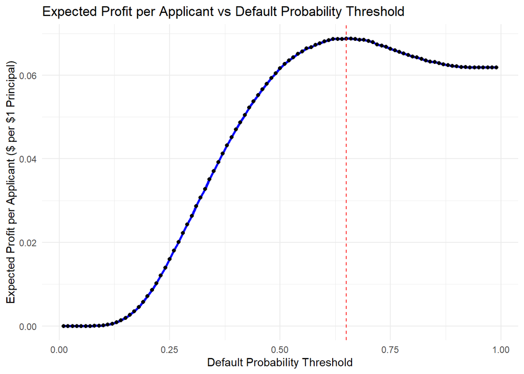

```
[1] 0 0 0
```

## 5. Model Interpretability

### 5.1 - Feature Importance

Top Predictive Features (based on LASSO coefficients, approximating feature impact)

| Feature | Coefficient |
| --- | --- |
| EXT_SOURCE_3 | -2.0878050 |
| EXT_SOURCE_2 | -2.0464835 |
| EXT_SOURCE_1 | -1.1814658 |
| LOAN_TO_GOODS | 0.7749824 |
| inst_ever_late_rate | 0.3634038 |
| prev_REFUSED_rate | 0.3521596 |
| NAME_EDUCATION_TYPESecondary / secondary special | 0.1660229 |
| CODE_GENDERM | 0.1624927 |
| pos_SK_DPD_DEF_ever_rate | 0.1062051 |
| ANNUITY_TO_INCOME | 0.1015247 |

**Note:** *These coefficients indicate the direction and relative strength of each feature’s contribution to predicted default probability. Positive coefficients increase predicted risk, while negative coefficients decrease it. This provides a SHAP-like interpretability for business understanding, without using actual SHAP values.*

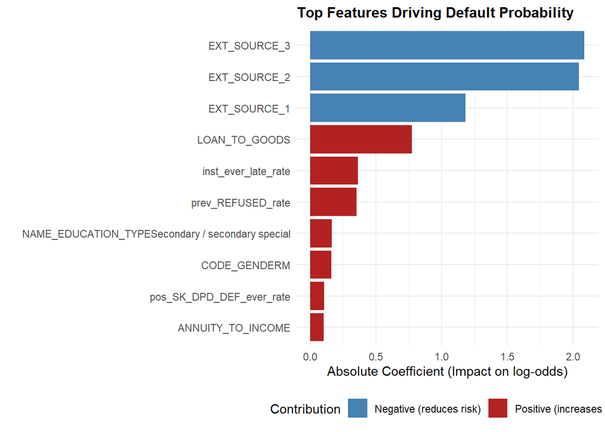

### 5.2 - Business Interpretation of Key Features

| Feature | Business Interpretation | Effect |
| --- | --- | --- |
| EXT_SOURCE_3 | Normalized external credit score | Higher score → **lower** risk of default |
| EXT_SOURCE_2 | Normalized external credit score | Higher score → **lower** risk of default |
| EXT_SOURCE_1 | Normalized external credit score | Higher score → **lower** risk of default |
| LOAN_TO_GOODS | Loan amount relative to goods price | Higher ratio → **higher** default risk |
| inst_ever_late_rate | Past installment payment lateness | Higher rate → **higher** default risk |
| prev_REFUSED_rate | Proportion of previously refused applications | Higher rate → **higher** default risk |
| NAME_EDUCATION_TYPE | Education level | Secondary / secondary special → **higher** default risk |
| CODE_GENDER | Client gender | Men → **higher** default risk |
| pos_SK_DPD_DEF_ever_rate | Past point-of-sale/default behavior | Higher rate → **higher** default risk |
| ANNUITY_TO_INCOME | Monthly payment relative to income | Higher ratio → **higher** default risk |

## 6. Adverse Action Mapping

This section translates the model’s top predictive features into human-readable reasons for loan denial. The purpose is to provide clear, actionable explanations for applicants and ensure compliance with regulatory requirements. Features that are only included for transparency, such as gender, are not used as denial reasons.

| Feature | Business Interpretation | Adverse Action Reason |
| --- | --- | --- |
| EXT_SOURCE_3 | Normalized external credit score | Low external credit score |
| EXT_SOURCE_2 | Normalized external credit score | Low external credit score |
| EXT_SOURCE_1 | Normalized external credit score | Low external credit score |
| LOAN_TO_GOODS | Loan amount relative to goods price | Requested loan too large relative to value of goods |
| inst_ever_late_rate | Past installment payment lateness | History of late payments |
| prev_REFUSED_rate | Proportion of previously refused applications | Prior loan applications were denied |
| NAME_EDUCATION_TYPE | Education level | Education level associated with higher risk |
| CODE_GENDER | Client gender | *N/A – included for transparency; cannot be used for loan denial* |
| pos_SK_DPD_DEF_ever_rate | Past point-of-sale/default behavior | Past defaults on small loans or POS loans |
| ANNUITY_TO_INCOME | Monthly payment relative to income | Monthly debt payments are high relative to income |

- **Note:** Denial of credit on the basis of gender is illegal under the Equal Credit Opportunity Act (ECOA).
  - The `CODE_GENDER` feature is included only for transparency and cannot be used in lending decisions.

## 7. Fairness Analysis

[output not shown]

[output not shown]

[output not shown]

**Ongoing Monitoring:**  
To ensure fairness, approval rates and model outputs will be regularly monitored across demographic groups. If significant disparities are observed, thresholds may be adjusted or models retrained, while never using protected features such as gender in decision-making.